# 삼성디스플레이 분기 실적 7분기 — 2025년 1분기~2026년 3분기

Alpha Hunter Sector Journal | 매출은 바닥을 지나 회복, 영업이익은 2025년 4분기 정점 이후 다시 올라오는 중

저자

Alpha Hunter

공개

2026년 11월 1일

## 1 핵심 요약

1. **2026년 3분기 매출 8.0조 원, 영업이익 1.1조 원.** 2025년 3분기와 비교하면 매출은 1% 줄었고 영업이익은 여전히 낮다.
2. **2025년 4분기가 7분기 중 최고점이다.** 매출 9.5조 원, 영업이익 2.0조 원을 기록했다.
3. **2026년 1분기에 바닥을 찍고 2, 3분기에 회복했다.** 매출은 6.7조 → 7.5조 → 8.0조 원, 영업이익은 0.4조 → 0.7조 → 1.1조 원으로 늘었다.
4. **연간으로는 2025년이 2024년보다 좋았다.** 매출 29.8조 원(+2%), 영업이익 4.1조 원(+11%)이다.

## 2 1. 분기별 실적

| 분기 | 매출 (조 원) | 영업이익 (조 원) | 전분기 대비 매출 |
| --- | --- | --- | --- |
| 2025년 1Q | 5.9 | 0.5 | — |
| 2025년 2Q | 6.4 | 0.5 | +8% |
| 2025년 3Q | 8.1 | 1.2 | +27% |
| 2025년 4Q | 9.5 | 2.0 | +17% |
| 2026년 1Q | 6.7 | 0.4 | -29% |
| 2026년 2Q | 7.5 | 0.7 | +12% |
| 2026년 3Q | 8.0 | 1.1 | +7% |

전분기 대비 매출 증감은 표에 적은 분기 매출을 기준으로 계산했다. 원자료 반올림 때문에 실제 증감률과 조금 다를 수 있다.

## 3 2. 분기 추이 그래프

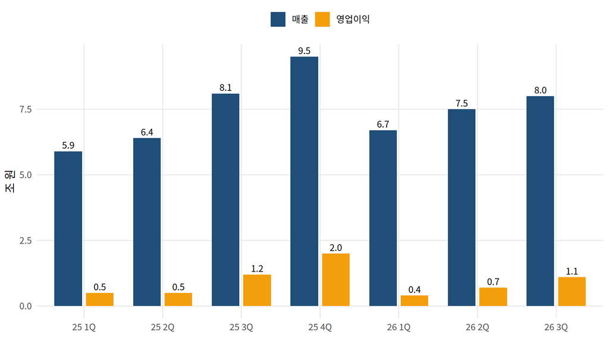

SDC 분기 매출과 영업이익 (단위: 조 원)

## 4 3. 읽는 법

**2025년 3분기부터 매출과 영업이익이 함께 올라갔고, 4분기에 영업이익이 2.0조 원으로 정점을 찍었다.** 이 표만으로는 2026년 1분기 하락의 원인을 확정할 수 없다. 원인 분해는 분기별 제품 믹스와 원가 자료가 있어야 가능하다.

**2026년은 회복 중이지만 2025년 4분기 수준에는 못 미친다.** 3분기 영업이익 1.1조 원은 2025년 3분기 1.2조 원과 비슷하다. 매출은 2025년 3분기보다 소폭 낮다. 4분기 정점과 비교하면 아직 회복 중이다.

**매출과 영업이익의 움직임이 다르다.** 2026년 1분기 매출은 2025년 4분기보다 29% 줄었지만 영업이익은 80% 가까이 줄었다. 매출이 줄 때 영업이익의 감소폭이 더 크다는 뜻이다. 반대로 2026년 2~3분기에는 매출이 소폭 늘어도 영업이익은 더 크게 늘었다. 원가와 믹스가 같이 개선됐다고 볼 수 있다.

## 5 4. 확인할 점

1. 부문 매출에는 삼성전자와의 내부 거래가 포함돼 있다. 외부 고객 매출만 분리한 값이 아니다.
2. 2026년 2분기 전사 실적은 잠정치로 발표됐다. 확정치와 차이가 날 수 있다.
3. 영업이익률은 삼성전자 IR 경영설명회 자료의 SDC 페이지에 적힌 공식 수치를 따른다. 2026년 1Q 5%, 2Q 9%, 3Q 14%다. 표의 금액으로 직접 나눈 값(1Q 0.4÷6.7≈6%)과 조금 다른 것은 금액을 소수점 한 자리로 반올림했기 때문이다.
4. 외부 리서치 기사(OLED-Info)의 2025년 4분기와 2026년 1분기 달러 환산 수치는 위 원화 금액과 대략 맞는다.

## 6 5. 원본 자료

- 2026년 3Q: [삼성전자 IR 경영설명회 자료](https://images.samsung.com/kdp/ir/events/2026/2026_3Q_conference_kor.pdf)
- 2026년 2Q: [삼성전자 IR 경영설명회 자료](https://images.samsung.com/kdp/ir/events/2026/2026_2Q_conference_kor.pdf)
- 2026년 1Q: [삼성전자 IR 경영설명회 자료](https://images.samsung.com/kdp/ir/events/2026/2026_1Q_conference_kor.pdf)
- 2025년 4Q: [삼성전자 IR 경영설명회 자료](https://images.samsung.com/kdp/ir/events/2025/2025_4Q_conference_kor.pdf)
- 2025년 3Q: [삼성전자 IR 경영설명회 자료](https://images.samsung.com/kdp/ir/events/2025/2025_3Q_conference_kor.pdf)
- 2025년 2Q: [삼성전자 IR 경영설명회 자료](https://images.samsung.com/kdp/ir/events/2025/2025_2Q_conference_kor.pdf)
- 2025년 1Q: [삼성전자 IR 경영설명회 자료](https://images.samsung.com/kdp/ir/events/2025/2025_1Q_conference_kor.pdf)

2026-11-01 대조: 2026년 1Q·2Q·3Q IR 자료의 SDC 페이지에서 7개 분기 매출과 영업이익을 모두 확인했고, 위 표와 일치한다. 2025년 1Q·4Q는 2026년 1Q 자료에, 2025년 2Q는 2026년 2Q 자료에, 2025년 3Q는 2026년 3Q 자료에 비교 수치로 실려 있다.

> 이 프로젝트는 가상 투자 시뮬레이션 목적으로 작성되었습니다. 실제 투자 권유가 아닙니다.